# Introduction

## Time Series Decomposition

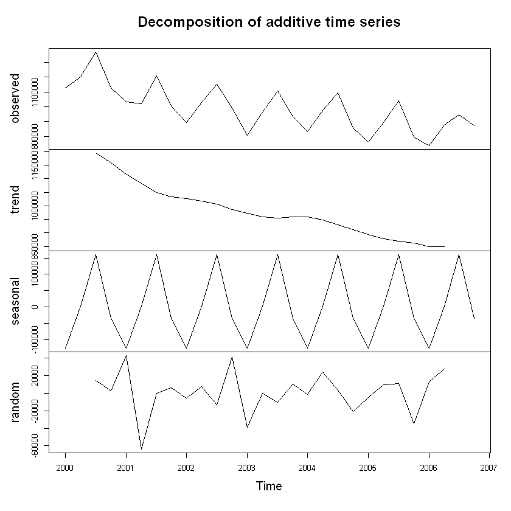

```r
dfts <- ts(df_tr$UGS, freq=4, start=c(2000,1))
dfts_dec_additive<-decompose(dfts, type="additive")
plot(dfts_dec_additive)
```

The above decomposition graph reveals the trend and the seasonality of the time series data. When the graph above is investigated, it can be seen that the time-series graph has a negative trend and the above seasonality.

## 2. Plotting the autocorrelation functions of the time series UGS

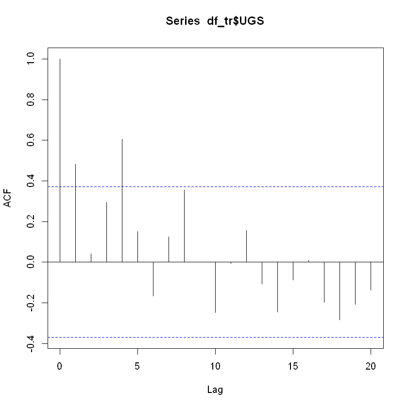

```r
acf(df_tr$UGS,lag.max=20)
```

When the autocorrelation function of the UGS variable is taken into consideration, it is seen that there is a correlation with variables having 4 quarters intervals in between. Therefore, when the model is constructed, the lag 4 variable of the UGS variable will be added to the model as well as the lag 1 variable of the UGS variable.

## 3. Adding Predictive Variables to the Data

### 3.1 Adding Seasonality and Trend Variables

```r
df_tr$quarter = rep(1:4,7)
df_tr$trend = seq(1,28,1)
df_tr
df_te$quarter = rep(1:4)
df_te$trend = seq(29,32,1)
df_te
df_tr$quarter = as.factor(df_tr$quarter)
df_tr$trend = as.integer(df_tr$trend)
df_te$quarter = as.factor(df_te$quarter)
df_te$trend = as.integer(df_te$trend)
```

| Quarter | UGS | RNUV | NLPG | PU | PG | NUGV | NDGV | GNPA | GNPC | GNP | quarter | trend |
| --- | --- | --- | --- | --- | --- | --- | --- | --- | --- | --- | --- | --- |
| 2000-01-01 | 1128971 | 0.0146 | 940000 | 469.03 | 355.69 | 4647500 | 281.9853 | 1040173 | 3483132 | 18022686 | 1 | 1 |
| 2000-04-01 | 1199569 | 0.0205 | 941000 | 459.42 | 344.58 | 4742876 | 284.0813 | 1760460 | 4525451 | 21797130 | 2 | 2 |
| 2000-07-01 | 1370167 | 0.0207 | 943500 | 439.98 | 327.21 | 4840931 | 286.7169 | 6974808 | 5915204 | 30050207 | 3 | 3 |
| 2000-10-01 | 1127548 | 0.0163 | 948000 | 402.08 | 300.67 | 4919685 | 288.3137 | 3267125 | 4929778 | 24480153 | 4 | 4 |
| 2001-01-01 | 1033918 | 0.0071 | 950000 | 411.58 | 305.75 | 4954754 | 287.6237 | 1004528 | 3418387 | 15832648 | 1 | 5 |
| 2001-04-01 | 1019754 | 0.0051 | 955000 | 520.39 | 374.78 | 4980204 | 287.8814 | 1449357 | 4359831 | 20296918 | 2 | 6 |
| 2001-07-01 | 1209916 | 0.0041 | 967500 | 530.37 | 398.71 | 5000446 | 287.5452 | 5890424 | 5925547 | 28017963 | 3 | 7 |
| 2001-10-01 | 1002789 | 0.0048 | 990000 | 496.35 | 370.70 | 5024693 | 286.9786 | 1940854 | 4559190 | 22656812 | 4 | 8 |
| 2002-01-01 | 893722 | 0.0012 | 1000000 | 479.52 | 352.72 | 5030810 | 286.3783 | 832953 | 3374849 | 18393446 | 1 | 9 |
| 2002-04-01 | 1027252 | 0.0032 | 1001000 | 506.36 | 373.44 | 5046960 | 286.0471 | 1419764 | 4363782 | 20382635 | 2 | 10 |
| 2002-07-01 | 1153265 | 0.0034 | 1003500 | 533.66 | 404.49 | 5064066 | 285.8790 | 6340745 | 6229580 | 29835296 | 3 | 11 |
| 2002-10-01 | 991981 | 0.0044 | 1008000 | 506.90 | 390.75 | 5086547 | 286.1087 | 2258470 | 5057739 | 25813612 | 4 | 12 |
| 2003-01-01 | 806257 | 0.0019 | 1010000 | 537.50 | 425.00 | 5096278 | 285.8286 | 841604 | 3933013 | 20084070 | 1 | 13 |
| 2003-04-01 | 960556 | 0.0056 | 1048000 | 502.06 | 382.47 | 5125065 | 286.2459 | 1519490 | 4395167 | 21769200 | 2 | 14 |
| 2003-07-01 | 1104825 | 0.0041 | 1143000 | 488.72 | 374.48 | 5146129 | 287.7798 | 6952669 | 6096102 | 30878474 | 3 | 15 |
| 2003-10-01 | 934022 | 0.0062 | 1314000 | 455.83 | 351.18 | 5178274 | 290.2288 | 2112006 | 5035207 | 25427354 | 4 | 16 |
| 2004-01-01 | 832350 | 0.0030 | 1390000 | 454.11 | 352.22 | 5193861 | 293.5030 | 1025366 | 4055284 | 20692122 | 1 | 17 |
| 2004-04-01 | 975165 | 0.0030 | 1401000 | 478.20 | 372.54 | 5209448 | 296.7488 | 1621092 | 5190860 | 24061451 | 2 | 18 |
| 2004-07-01 | 1094823 | 0.0051 | 1428500 | 522.95 | 408.34 | 5236227 | 298.6176 | 6932300 | 6886243 | 33270727 | 3 | 19 |
| 2004-10-01 | 854517 | 0.0181 | 1478000 | 561.67 | 438.75 | 5330892 | 303.1641 | 2408982 | 5847940 | 28644792 | 4 | 20 |
| 2005-01-01 | 762559 | 0.0035 | 1500000 | 571.48 | 438.67 | 5349584 | 305.5032 | 1027640 | 4405719 | 22144043 | 1 | 21 |
| 2005-04-01 | 890693 | 0.0131 | 1512000 | 591.14 | 456.19 | 5419927 | 310.4279 | 1424674 | 5308303 | 25032070 | 2 | 22 |
| 2005-07-01 | 1040946 | 0.0162 | 1542000 | 609.03 | 471.86 | 5507485 | 316.2897 | 6476845 | 6784956 | 33325846 | 3 | 23 |
| 2005-10-01 | 793399 | 0.0158 | 1596000 | 565.19 | 449.19 | 5594288 | 322.2079 | 2193688 | 5802943 | 28445453 | 4 | 24 |
| 2006-01-01 | 736580 | 0.0080 | 1620000 | 565.19 | 449.19 | 5635972 | 324.9761 | 1079022 | 4626005 | 23251245 | 1 | 25 |
| 2006-04-01 | 877614 | 0.0114 | 1629500 | 565.19 | 449.19 | 5696182 | 329.4702 | 1495908 | 5573718 | 26283673 | 2 | 26 |
| 2006-07-01 | 946783 | 0.0108 | 1653250 | 565.19 | 449.19 | 5754077 | 333.7144 | 6800688 | 7124204 | 34992138 | 3 | 27 |
| 2006-10-01 | 872000 | 0.0133 | 1696000 | 565.19 | 449.19 | 5825866 | 339.2281 | 2303373 | 6093090 | 29867726 | 4 | 28 |

|  | Quarter | UGS | RNUV | NLPG | PU | PG | NUGV | NDGV | GNPA | GNPC | GNP | quarter | trend |
| --- | --- | --- | --- | --- | --- | --- | --- | --- | --- | --- | --- | --- | --- |
| 29 | 2007-01-01 | NA | 0.0074 | 1715000 | 565.19 | 449.19 | 5869018 | 342.1729 | 1132973 | 4857305 | 24413807 | 1 | 29 |
| 30 | 2007-04-01 | NA | 0.0106 | 1725300 | 565.19 | 449.19 | 5931348 | 346.9407 | 1570703 | 5852404 | 27597857 | 2 | 30 |
| 31 | 2007-07-01 | NA | 0.0101 | 1751050 | 565.19 | 449.19 | 5991280 | 351.4449 | 7140722 | 7480414 | 36741745 | 3 | 31 |
| 32 | 2007-10-01 | NA | 0.0124 | 1797400 | 565.19 | 449.19 | 6065597 | 357.2902 | 2418541 | 6397745 | 31361112 | 4 | 32 |

### 3.2 Adding lag_1 and lag_4 of UGS to the data

```r
Y_t_1 = c()
for( i in 2:nrow(df_tr)){
    Y_t_1[i] = df_tr$UGS[i-1]
}
Y_t_4 = c()
for( i in 5:nrow(df_tr)){
    Y_t_4[i] = df_tr$UGS[i-4]
}
```

```r
df_tr = cbind(df_tr,Y_t_1,Y_t_4)
df_tr
df_te
```

| Quarter | UGS | RNUV | NLPG | PU | PG | NUGV | NDGV | GNPA | GNPC | GNP | quarter | trend | Y_t_1 | Y_t_4 |
| --- | --- | --- | --- | --- | --- | --- | --- | --- | --- | --- | --- | --- | --- | --- |
| 2000-01-01 | 1128971 | 0.0146 | 940000 | 469.03 | 355.69 | 4647500 | 281.9853 | 1040173 | 3483132 | 18022686 | 1 | 1 | NA | NA |
| 2000-04-01 | 1199569 | 0.0205 | 941000 | 459.42 | 344.58 | 4742876 | 284.0813 | 1760460 | 4525451 | 21797130 | 2 | 2 | 1128971 | NA |
| 2000-07-01 | 1370167 | 0.0207 | 943500 | 439.98 | 327.21 | 4840931 | 286.7169 | 6974808 | 5915204 | 30050207 | 3 | 3 | 1199569 | NA |
| 2000-10-01 | 1127548 | 0.0163 | 948000 | 402.08 | 300.67 | 4919685 | 288.3137 | 3267125 | 4929778 | 24480153 | 4 | 4 | 1370167 | NA |
| 2001-01-01 | 1033918 | 0.0071 | 950000 | 411.58 | 305.75 | 4954754 | 287.6237 | 1004528 | 3418387 | 15832648 | 1 | 5 | 1127548 | 1128971 |
| 2001-04-01 | 1019754 | 0.0051 | 955000 | 520.39 | 374.78 | 4980204 | 287.8814 | 1449357 | 4359831 | 20296918 | 2 | 6 | 1033918 | 1199569 |
| 2001-07-01 | 1209916 | 0.0041 | 967500 | 530.37 | 398.71 | 5000446 | 287.5452 | 5890424 | 5925547 | 28017963 | 3 | 7 | 1019754 | 1370167 |
| 2001-10-01 | 1002789 | 0.0048 | 990000 | 496.35 | 370.70 | 5024693 | 286.9786 | 1940854 | 4559190 | 22656812 | 4 | 8 | 1209916 | 1127548 |
| 2002-01-01 | 893722 | 0.0012 | 1000000 | 479.52 | 352.72 | 5030810 | 286.3783 | 832953 | 3374849 | 18393446 | 1 | 9 | 1002789 | 1033918 |
| 2002-04-01 | 1027252 | 0.0032 | 1001000 | 506.36 | 373.44 | 5046960 | 286.0471 | 1419764 | 4363782 | 20382635 | 2 | 10 | 893722 | 1019754 |
| 2002-07-01 | 1153265 | 0.0034 | 1003500 | 533.66 | 404.49 | 5064066 | 285.8790 | 6340745 | 6229580 | 29835296 | 3 | 11 | 1027252 | 1209916 |
| 2002-10-01 | 991981 | 0.0044 | 1008000 | 506.90 | 390.75 | 5086547 | 286.1087 | 2258470 | 5057739 | 25813612 | 4 | 12 | 1153265 | 1002789 |
| 2003-01-01 | 806257 | 0.0019 | 1010000 | 537.50 | 425.00 | 5096278 | 285.8286 | 841604 | 3933013 | 20084070 | 1 | 13 | 991981 | 893722 |
| 2003-04-01 | 960556 | 0.0056 | 1048000 | 502.06 | 382.47 | 5125065 | 286.2459 | 1519490 | 4395167 | 21769200 | 2 | 14 | 806257 | 1027252 |
| 2003-07-01 | 1104825 | 0.0041 | 1143000 | 488.72 | 374.48 | 5146129 | 287.7798 | 6952669 | 6096102 | 30878474 | 3 | 15 | 960556 | 1153265 |
| 2003-10-01 | 934022 | 0.0062 | 1314000 | 455.83 | 351.18 | 5178274 | 290.2288 | 2112006 | 5035207 | 25427354 | 4 | 16 | 1104825 | 991981 |
| 2004-01-01 | 832350 | 0.0030 | 1390000 | 454.11 | 352.22 | 5193861 | 293.5030 | 1025366 | 4055284 | 20692122 | 1 | 17 | 934022 | 806257 |
| 2004-04-01 | 975165 | 0.0030 | 1401000 | 478.20 | 372.54 | 5209448 | 296.7488 | 1621092 | 5190860 | 24061451 | 2 | 18 | 832350 | 960556 |
| 2004-07-01 | 1094823 | 0.0051 | 1428500 | 522.95 | 408.34 | 5236227 | 298.6176 | 6932300 | 6886243 | 33270727 | 3 | 19 | 975165 | 1104825 |
| 2004-10-01 | 854517 | 0.0181 | 1478000 | 561.67 | 438.75 | 5330892 | 303.1641 | 2408982 | 5847940 | 28644792 | 4 | 20 | 1094823 | 934022 |
| 2005-01-01 | 762559 | 0.0035 | 1500000 | 571.48 | 438.67 | 5349584 | 305.5032 | 1027640 | 4405719 | 22144043 | 1 | 21 | 854517 | 832350 |
| 2005-04-01 | 890693 | 0.0131 | 1512000 | 591.14 | 456.19 | 5419927 | 310.4279 | 1424674 | 5308303 | 25032070 | 2 | 22 | 762559 | 975165 |
| 2005-07-01 | 1040946 | 0.0162 | 1542000 | 609.03 | 471.86 | 5507485 | 316.2897 | 6476845 | 6784956 | 33325846 | 3 | 23 | 890693 | 1094823 |
| 2005-10-01 | 793399 | 0.0158 | 1596000 | 565.19 | 449.19 | 5594288 | 322.2079 | 2193688 | 5802943 | 28445453 | 4 | 24 | 1040946 | 854517 |
| 2006-01-01 | 736580 | 0.0080 | 1620000 | 565.19 | 449.19 | 5635972 | 324.9761 | 1079022 | 4626005 | 23251245 | 1 | 25 | 793399 | 762559 |
| 2006-04-01 | 877614 | 0.0114 | 1629500 | 565.19 | 449.19 | 5696182 | 329.4702 | 1495908 | 5573718 | 26283673 | 2 | 26 | 736580 | 890693 |
| 2006-07-01 | 946783 | 0.0108 | 1653250 | 565.19 | 449.19 | 5754077 | 333.7144 | 6800688 | 7124204 | 34992138 | 3 | 27 | 877614 | 1040946 |
| 2006-10-01 | 872000 | 0.0133 | 1696000 | 565.19 | 449.19 | 5825866 | 339.2281 | 2303373 | 6093090 | 29867726 | 4 | 28 | 946783 | 793399 |

|  | Quarter | UGS | RNUV | NLPG | PU | PG | NUGV | NDGV | GNPA | GNPC | GNP | quarter | trend |
| --- | --- | --- | --- | --- | --- | --- | --- | --- | --- | --- | --- | --- | --- |
| 29 | 2007-01-01 | NA | 0.0074 | 1715000 | 565.19 | 449.19 | 5869018 | 342.1729 | 1132973 | 4857305 | 24413807 | 1 | 29 |
| 30 | 2007-04-01 | NA | 0.0106 | 1725300 | 565.19 | 449.19 | 5931348 | 346.9407 | 1570703 | 5852404 | 27597857 | 2 | 30 |
| 31 | 2007-07-01 | NA | 0.0101 | 1751050 | 565.19 | 449.19 | 5991280 | 351.4449 | 7140722 | 7480414 | 36741745 | 3 | 31 |
| 32 | 2007-10-01 | NA | 0.0124 | 1797400 | 565.19 | 449.19 | 6065597 | 357.2902 | 2418541 | 6397745 | 31361112 | 4 | 32 |